#### *Data Exploration*

Load the data into R dataframe.

```r
library(plyr)
library(dplyr)
library(pastecs)
library(corrplot)
library(caTools)
library(randomForest)
library(caret)
library(party)
library(gridExtra)

setwd("/Volumes/Meghna/Marketing Analytics/Analyses/Customer Churn")
dfCustomer <- read.csv(file="Telco-Customer-Churn.csv", header = TRUE, sep = ",")
print(str(dfCustomer))
```

```
## 'data.frame':    7043 obs. of  21 variables:
##  $ customerID      : Factor w/ 7043 levels "0002-ORFBO","0003-MKNFE",..: 5376 3963 2565 5536 6512 6552 1003 4771 5605 4535 ...
##  $ gender          : Factor w/ 2 levels "Female","Male": 1 2 2 2 1 1 2 1 1 2 ...
##  $ SeniorCitizen   : int  0 0 0 0 0 0 0 0 0 0 ...
##  $ Partner         : Factor w/ 2 levels "No","Yes": 2 1 1 1 1 1 1 1 2 1 ...
##  $ Dependents      : Factor w/ 2 levels "No","Yes": 1 1 1 1 1 1 2 1 1 2 ...
##  $ tenure          : int  1 34 2 45 2 8 22 10 28 62 ...
##  $ PhoneService    : Factor w/ 2 levels "No","Yes": 1 2 2 1 2 2 2 1 2 2 ...
##  $ MultipleLines   : Factor w/ 3 levels "No","No phone service",..: 2 1 1 2 1 3 3 2 3 1 ...
##  $ InternetService : Factor w/ 3 levels "DSL","Fiber optic",..: 1 1 1 1 2 2 2 1 2 1 ...
##  $ OnlineSecurity  : Factor w/ 3 levels "No","No internet service",..: 1 3 3 3 1 1 1 3 1 3 ...
##  $ OnlineBackup    : Factor w/ 3 levels "No","No internet service",..: 3 1 3 1 1 1 3 1 1 3 ...
##  $ DeviceProtection: Factor w/ 3 levels "No","No internet service",..: 1 3 1 3 1 3 1 1 3 1 ...
##  $ TechSupport     : Factor w/ 3 levels "No","No internet service",..: 1 1 1 3 1 1 1 1 3 1 ...
##  $ StreamingTV     : Factor w/ 3 levels "No","No internet service",..: 1 1 1 1 1 3 3 1 3 1 ...
##  $ StreamingMovies : Factor w/ 3 levels "No","No internet service",..: 1 1 1 1 1 3 1 1 3 1 ...
##  $ Contract        : Factor w/ 3 levels "Month-to-month",..: 1 2 1 2 1 1 1 1 1 2 ...
##  $ PaperlessBilling: Factor w/ 2 levels "No","Yes": 2 1 2 1 2 2 2 1 2 1 ...
##  $ PaymentMethod   : Factor w/ 4 levels "Bank transfer (automatic)",..: 3 4 4 1 3 3 2 4 3 1 ...
##  $ MonthlyCharges  : num  29.9 57 53.9 42.3 70.7 ...
##  $ TotalCharges    : num  29.9 1889.5 108.2 1840.8 151.7 ...
##  $ Churn           : Factor w/ 2 levels "No","Yes": 1 1 2 1 2 2 1 1 2 1 ...
## NULL
```

Check for missing values and drop those rows

```r
sapply(dfCustomer, function(x) sum(is.na(x)))
```

```
##       customerID           gender    SeniorCitizen          Partner
##                0                0                0                0
##       Dependents           tenure     PhoneService    MultipleLines
##                0                0                0                0
##  InternetService   OnlineSecurity     OnlineBackup DeviceProtection
##                0                0                0                0
##      TechSupport      StreamingTV  StreamingMovies         Contract
##                0                0                0                0
## PaperlessBilling    PaymentMethod   MonthlyCharges     TotalCharges
##                0                0                0               11
##            Churn
##                0
```

```r
dfCustomer <- dfCustomer[complete.cases(dfCustomer), ]
```

Change seniorcitizen from numerical to categorical

```r
dfCustomer$SeniorCitizen <- as.factor(mapvalues(dfCustomer$SeniorCitizen,from=c("0","1"),to=c("No", "Yes")))
```

Group “tenure” to change it from continuous to categorical

```r
group_tenure <- function(tenure){
  if (tenure >= 0 & tenure <= 12){
    return('0-12 Month')
  }else if(tenure > 12 & tenure <= 24){
    return('12-24 Month')
  }else if (tenure > 24 & tenure <= 48){
    return('24-48 Month')
  }else if (tenure > 48 & tenure <=60){
    return('48-60 Month')
  }else if (tenure > 60){
    return('> 60 Month')
  }
}
dfCustomer$tenure_group <- sapply(dfCustomer$tenure,group_tenure)
dfCustomer$tenure_group <- as.factor(dfCustomer$tenure_group)
```

Remove the columns we do not need for the analysis.

```r
dfCustomer$customerID <- NULL
dfCustomer$tenure <- NULL
print(str(dfCustomer))
```

```
## 'data.frame':    7032 obs. of  20 variables:
##  $ gender          : Factor w/ 2 levels "Female","Male": 1 2 2 2 1 1 2 1 1 2 ...
##  $ SeniorCitizen   : Factor w/ 2 levels "No","Yes": 1 1 1 1 1 1 1 1 1 1 ...
##  $ Partner         : Factor w/ 2 levels "No","Yes": 2 1 1 1 1 1 1 1 2 1 ...
##  $ Dependents      : Factor w/ 2 levels "No","Yes": 1 1 1 1 1 1 2 1 1 2 ...
##  $ PhoneService    : Factor w/ 2 levels "No","Yes": 1 2 2 1 2 2 2 1 2 2 ...
##  $ MultipleLines   : Factor w/ 2 levels "No","Yes": 1 1 1 1 1 2 2 1 2 1 ...
##  $ InternetService : Factor w/ 3 levels "DSL","Fiber optic",..: 1 1 1 1 2 2 2 1 2 1 ...
##  $ OnlineSecurity  : Factor w/ 2 levels "No","Yes": 1 2 2 2 1 1 1 2 1 2 ...
##  $ OnlineBackup    : Factor w/ 2 levels "No","Yes": 2 1 2 1 1 1 2 1 1 2 ...
##  $ DeviceProtection: Factor w/ 2 levels "No","Yes": 1 2 1 2 1 2 1 1 2 1 ...
##  $ TechSupport     : Factor w/ 2 levels "No","Yes": 1 1 1 2 1 1 1 1 2 1 ...
##  $ StreamingTV     : Factor w/ 2 levels "No","Yes": 1 1 1 1 1 2 2 1 2 1 ...
##  $ StreamingMovies : Factor w/ 2 levels "No","Yes": 1 1 1 1 1 2 1 1 2 1 ...
##  $ Contract        : Factor w/ 3 levels "Month-to-month",..: 1 2 1 2 1 1 1 1 1 2 ...
##  $ PaperlessBilling: Factor w/ 2 levels "No","Yes": 2 1 2 1 2 2 2 1 2 1 ...
##  $ PaymentMethod   : Factor w/ 4 levels "Bank transfer (automatic)",..: 3 4 4 1 3 3 2 4 3 1 ...
##  $ MonthlyCharges  : num  29.9 57 53.9 42.3 70.7 ...
##  $ TotalCharges    : num  29.9 1889.5 108.2 1840.8 151.7 ...
##  $ Churn           : Factor w/ 2 levels "No","Yes": 1 1 2 1 2 2 1 1 2 1 ...
##  $ tenure_group    : Factor w/ 5 levels "> 60 Month","0-12 Month",..: 2 4 2 4 2 2 3 2 4 1 ...
## NULL
```

Convert character data into factors

```r
dfCustomer$Churn <- as.factor(dfCustomer$Churn)
dfCustomer$gender <- as.factor(dfCustomer$gender)
dfCustomer$PaperlessBilling <- as.factor(dfCustomer$PaperlessBilling)
dfCustomer$Contract <- as.factor(dfCustomer$Contract)
dfCustomer$Partner <- as.factor(dfCustomer$Partner)
dfCustomer$Dependents <- as.factor(dfCustomer$Dependents)
dfCustomer$PhoneService <- as.factor(dfCustomer$PhoneService)
print(str(dfCustomer))
```

```
## 'data.frame':    7032 obs. of  20 variables:
##  $ gender          : Factor w/ 2 levels "Female","Male": 1 2 2 2 1 1 2 1 1 2 ...
##  $ SeniorCitizen   : Factor w/ 2 levels "No","Yes": 1 1 1 1 1 1 1 1 1 1 ...
##  $ Partner         : Factor w/ 2 levels "No","Yes": 2 1 1 1 1 1 1 1 2 1 ...
##  $ Dependents      : Factor w/ 2 levels "No","Yes": 1 1 1 1 1 1 2 1 1 2 ...
##  $ PhoneService    : Factor w/ 2 levels "No","Yes": 1 2 2 1 2 2 2 1 2 2 ...
##  $ MultipleLines   : Factor w/ 2 levels "No","Yes": 1 1 1 1 1 2 2 1 2 1 ...
##  $ InternetService : Factor w/ 3 levels "DSL","Fiber optic",..: 1 1 1 1 2 2 2 1 2 1 ...
##  $ OnlineSecurity  : Factor w/ 2 levels "No","Yes": 1 2 2 2 1 1 1 2 1 2 ...
##  $ OnlineBackup    : Factor w/ 2 levels "No","Yes": 2 1 2 1 1 1 2 1 1 2 ...
##  $ DeviceProtection: Factor w/ 2 levels "No","Yes": 1 2 1 2 1 2 1 1 2 1 ...
##  $ TechSupport     : Factor w/ 2 levels "No","Yes": 1 1 1 2 1 1 1 1 2 1 ...
##  $ StreamingTV     : Factor w/ 2 levels "No","Yes": 1 1 1 1 1 2 2 1 2 1 ...
##  $ StreamingMovies : Factor w/ 2 levels "No","Yes": 1 1 1 1 1 2 1 1 2 1 ...
##  $ Contract        : Factor w/ 3 levels "Month-to-month",..: 1 2 1 2 1 1 1 1 1 2 ...
##  $ PaperlessBilling: Factor w/ 2 levels "No","Yes": 2 1 2 1 2 2 2 1 2 1 ...
##  $ PaymentMethod   : Factor w/ 4 levels "Bank transfer (automatic)",..: 3 4 4 1 3 3 2 4 3 1 ...
##  $ MonthlyCharges  : num  29.9 57 53.9 42.3 70.7 ...
##  $ TotalCharges    : num  29.9 1889.5 108.2 1840.8 151.7 ...
##  $ Churn           : Factor w/ 2 levels "No","Yes": 1 1 2 1 2 2 1 1 2 1 ...
##  $ tenure_group    : Factor w/ 5 levels "> 60 Month","0-12 Month",..: 2 4 2 4 2 2 3 2 4 1 ...
## NULL
```

**Summary Statistics**

```r
numeric_var <- sapply(dfCustomer, is.numeric)
options(scipen=100)
options(digits = 2)
stat.desc(dfCustomer[,numeric_var])
```

```
##              MonthlyCharges TotalCharges
## nbr.val             7032.00      7032.00
## nbr.null               0.00         0.00
## nbr.na                 0.00         0.00
## min                   18.25        18.80
## max                  118.75      8684.80
## range                100.50      8666.00
## sum               455661.00  16056168.70
## median                70.35      1397.47
## mean                  64.80      2283.30
## SE.mean                0.36        27.03
## CI.mean.0.95           0.70        52.99
## var                  905.17   5138252.41
## std.dev               30.09      2266.77
## coef.var               0.46         0.99
```

Bar plots for categorical variables

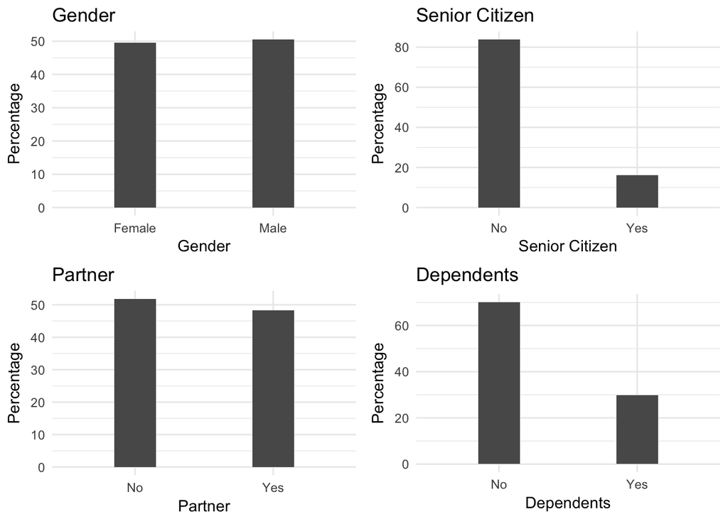

```r
p1 <- ggplot(dfCustomer, aes(x=gender)) + ggtitle("Gender") + xlab("Gender") +
  geom_bar(aes(y = 100*(..count..)/sum(..count..)), width = 0.3) + ylab("Percentage") + theme_minimal()

p2 <- ggplot(dfCustomer, aes(x=SeniorCitizen)) + ggtitle("Senior Citizen") + xlab("Senior Citizen") +
  geom_bar(aes(y = 100*(..count..)/sum(..count..)), width = 0.3) + ylab("Percentage") + theme_minimal()

p3 <- ggplot(dfCustomer, aes(x=Partner)) + ggtitle("Partner") + xlab("Partner") +
  geom_bar(aes(y = 100*(..count..)/sum(..count..)), width = 0.3) + ylab("Percentage")  + theme_minimal()

p4 <- ggplot(dfCustomer, aes(x=Dependents)) + ggtitle("Dependents") + xlab("Dependents") +
  geom_bar(aes(y = 100*(..count..)/sum(..count..)), width = 0.3) + ylab("Percentage") + theme_minimal()
grid.arrange(p1, p2, p3, p4, ncol=2)
```

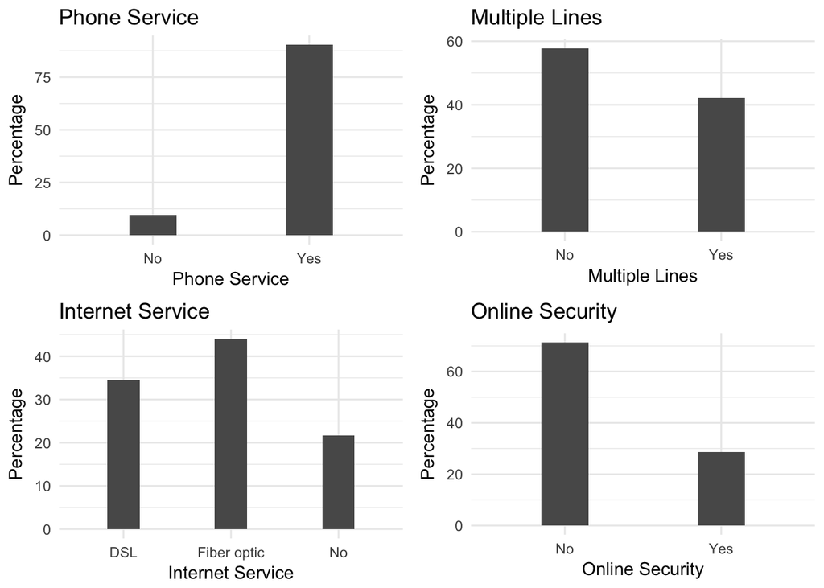

```r
p5 <- ggplot(dfCustomer, aes(x=PhoneService)) + ggtitle("Phone Service") + xlab("Phone Service") +
  geom_bar(aes(y = 100*(..count..)/sum(..count..)), width = 0.3) + ylab("Percentage") + theme_minimal()

p6 <- ggplot(dfCustomer, aes(x=MultipleLines)) + ggtitle("Multiple Lines") + xlab("Multiple Lines") +
  geom_bar(aes(y = 100*(..count..)/sum(..count..)), width = 0.3) + ylab("Percentage") + theme_minimal()

p7 <- ggplot(dfCustomer, aes(x=InternetService)) + ggtitle("Internet Service") + xlab("Internet Service") +
  geom_bar(aes(y = 100*(..count..)/sum(..count..)), width = 0.3) + ylab("Percentage")  + theme_minimal()

p8 <- ggplot(dfCustomer, aes(x=OnlineSecurity)) + ggtitle("Online Security") + xlab("Online Security") +
  geom_bar(aes(y = 100*(..count..)/sum(..count..)), width = 0.3) + ylab("Percentage") + theme_minimal()
grid.arrange(p5, p6, p7, p8, ncol=2)
```

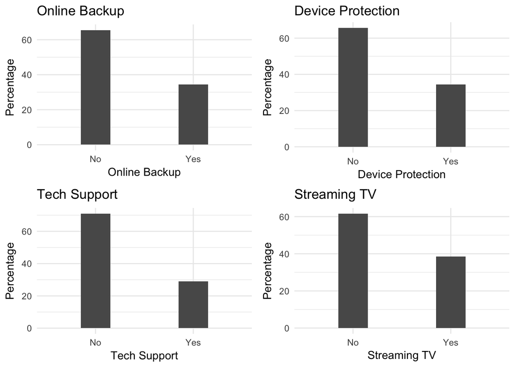

```r
p9 <- ggplot(dfCustomer, aes(x=OnlineBackup)) + ggtitle("Online Backup") + xlab("Online Backup") +
  geom_bar(aes(y = 100*(..count..)/sum(..count..)), width = 0.3) + ylab("Percentage")+ theme_minimal()

p10 <- ggplot(dfCustomer, aes(x=DeviceProtection)) + ggtitle("Device Protection") + xlab("Device Protection") +
  geom_bar(aes(y = 100*(..count..)/sum(..count..)), width = 0.3) + ylab("Percentage")  + theme_minimal()

p11 <- ggplot(dfCustomer, aes(x=TechSupport)) + ggtitle("Tech Support") + xlab("Tech Support") +
  geom_bar(aes(y = 100*(..count..)/sum(..count..)), width = 0.3) + ylab("Percentage")+ theme_minimal()

p12 <- ggplot(dfCustomer, aes(x=StreamingTV)) + ggtitle("Streaming TV") + xlab("Streaming TV") +
  geom_bar(aes(y = 100*(..count..)/sum(..count..)), width = 0.3) + ylab("Percentage")  + theme_minimal()
grid.arrange(p9, p10, p11, p12, ncol=2)
```

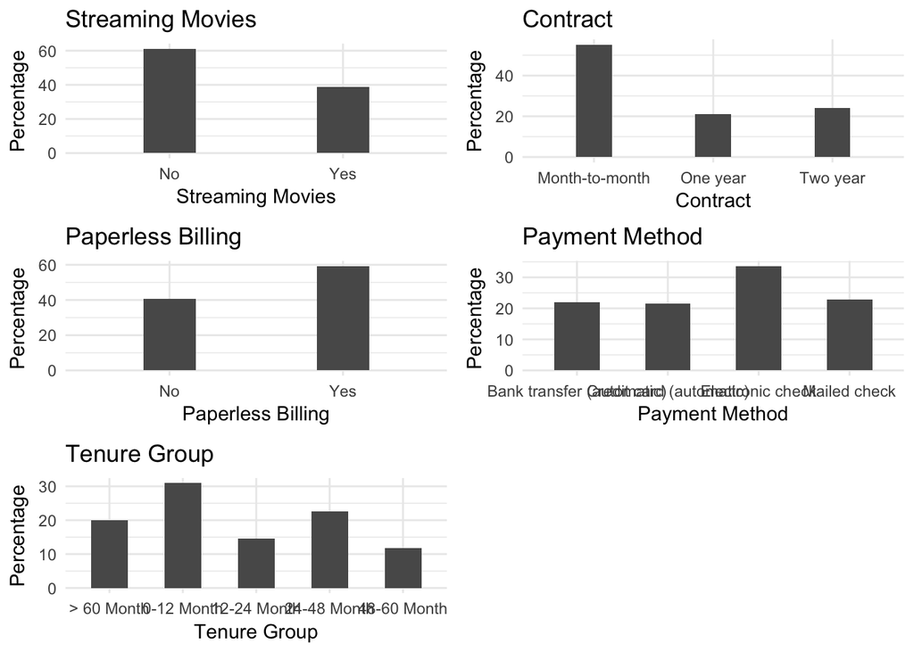

```r
p13 <- ggplot(dfCustomer, aes(x=StreamingMovies)) + ggtitle("Streaming Movies") + xlab("Streaming Movies") +
  geom_bar(aes(y = 100*(..count..)/sum(..count..)), width = 0.3) + ylab("Percentage") + theme_minimal()

p14 <- ggplot(dfCustomer, aes(x=Contract)) + ggtitle("Contract") + xlab("Contract") +
  geom_bar(aes(y = 100*(..count..)/sum(..count..)), width = 0.3) + ylab("Percentage")  + theme_minimal()

p15 <- ggplot(dfCustomer, aes(x=PaperlessBilling)) + ggtitle("Paperless Billing") + xlab("Paperless Billing") +
  geom_bar(aes(y = 100*(..count..)/sum(..count..)), width = 0.3) + ylab("Percentage") + theme_minimal()

p16 <- ggplot(dfCustomer, aes(x=PaymentMethod)) + ggtitle("Payment Method") + xlab("Payment Method") +
  geom_bar(aes(y = 100*(..count..)/sum(..count..)), width = 0.5) + ylab("Percentage") + theme_minimal()

p17 <- ggplot(dfCustomer, aes(x=tenure_group)) + ggtitle("Tenure Group") + xlab("Tenure Group") +
  geom_bar(aes(y = 100*(..count..)/sum(..count..)), width = 0.5) + ylab("Percentage") + theme_minimal()
grid.arrange(p13, p14, p15, p16, p17, ncol=2)
```

#### *Feature Selection*

Numeric Variables using correlation matrix

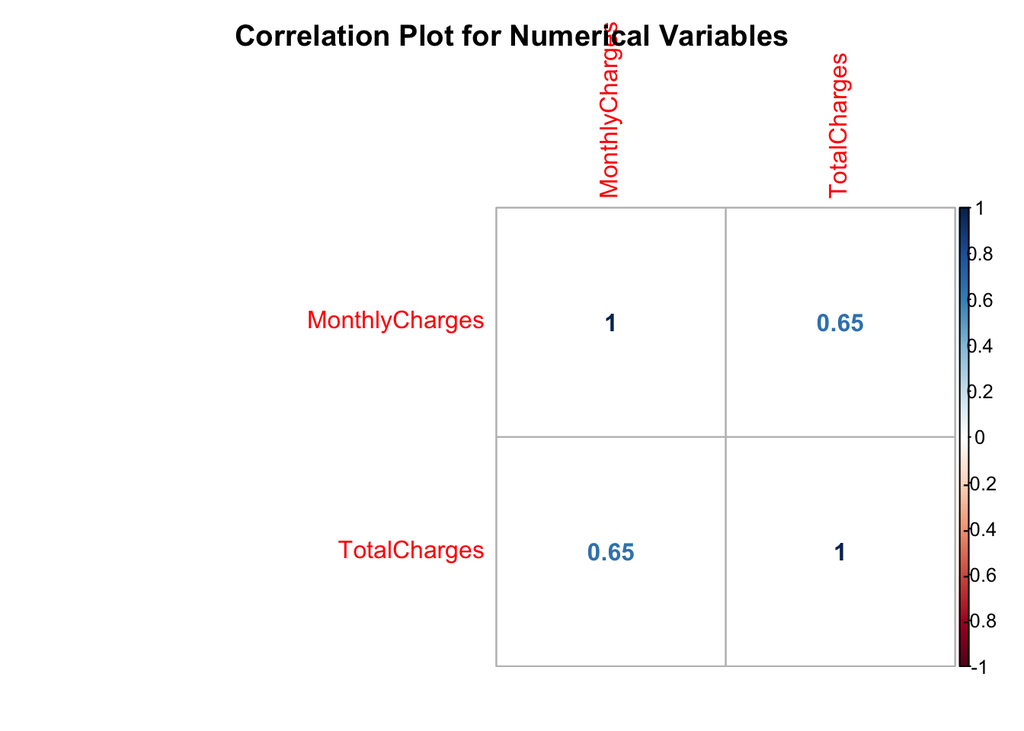

```r
corr.matrix <- cor(dfCustomer[,numeric_var])
corrplot(corr.matrix, main="\n\nCorrelation Plot for Numerical Variables", method="number")
```

```r
dfCustomer$TotalCharges <- NULL #reomve totalcharges because it is correlated to monthlycharges
```

```r
#chisq.test(dfCustomer$Partner, dfCustomer$Churn, correct=FALSE)
```

**Data Partitioning**

Sample the input data with 70% for training and 30% for testing

```r
set.seed(2017) #Set the seed, it will output same output when ever the model is executed.
sample <- sample.split(dfCustomer$Churn,SplitRatio=0.70)
trainData <- subset(dfCustomer,sample==TRUE)
testData <- subset(dfCustomer,sample==FALSE)
dim(trainData); dim(testData) #Confirm the splitting is correct.
```

```
## [1] 4922   19
```

```
## [1] 2110   19
```

#### *Model Building*

**Logistic Regression**

```r
telecomModel <- glm(Churn ~ .,family=binomial(link="logit"),data=trainData)
print(summary(telecomModel))
```

```
##
## Call:
## glm(formula = Churn ~ ., family = binomial(link = "logit"), data = trainData)
##
## Deviance Residuals:
##    Min      1Q  Median      3Q     Max
## -2.023  -0.677  -0.283   0.683   3.177
##
## Coefficients:
##                                      Estimate Std. Error z value
## (Intercept)                          -1.58324    0.99581   -1.59
## genderMale                           -0.02489    0.07745   -0.32
## SeniorCitizenYes                      0.37619    0.10037    3.75
## PartnerYes                            0.00643    0.09129    0.07
## DependentsYes                        -0.14039    0.10620   -1.32
## PhoneServiceYes                      -0.00327    0.77896    0.00
## MultipleLinesYes                      0.31229    0.21165    1.48
## InternetServiceFiber optic            1.34570    0.95745    1.41
## InternetServiceNo                    -1.17025    0.96834   -1.21
## OnlineSecurityYes                    -0.21190    0.21270   -1.00
## OnlineBackupYes                      -0.05523    0.21036   -0.26
## DeviceProtectionYes                   0.03690    0.21088    0.17
## TechSupportYes                       -0.12806    0.21590   -0.59
## StreamingTVYes                        0.44410    0.39148    1.13
## StreamingMoviesYes                    0.48884    0.39255    1.25
## ContractOne year                     -0.84228    0.13038   -6.46
## ContractTwo year                     -1.93991    0.23314   -8.32
## PaperlessBillingYes                   0.35032    0.08925    3.93
## PaymentMethodCredit card (automatic) -0.12075    0.13658   -0.88
## PaymentMethodElectronic check         0.24377    0.11383    2.14
## PaymentMethodMailed check            -0.07386    0.13572   -0.54
## MonthlyCharges                       -0.01863    0.03806   -0.49
## tenure_group0-12 Month                1.72404    0.20732    8.32
## tenure_group12-24 Month               0.94181    0.20382    4.62
## tenure_group24-48 Month               0.39455    0.18776    2.10
## tenure_group48-60 Month               0.18911    0.20709    0.91
##                                                  Pr(>|z|)
## (Intercept)                                       0.11186
## genderMale                                        0.74790
## SeniorCitizenYes                                  0.00018 ***
```

[output cut: 18 more lines]

```
## MonthlyCharges                                    0.62456
## tenure_group0-12 Month               < 0.0000000000000002 ***
## tenure_group12-24 Month                      0.0000038223 ***
## tenure_group24-48 Month                           0.03560 *
## tenure_group48-60 Month                           0.36115
## ---
## Signif. codes:  0 '***' 0.001 '**' 0.01 '*' 0.05 '.' 0.1 ' ' 1
##
## (Dispersion parameter for binomial family taken to be 1)
##
##     Null deviance: 5699.5  on 4921  degrees of freedom
## Residual deviance: 4092.6  on 4896  degrees of freedom
## AIC: 4145
##
## Number of Fisher Scoring iterations: 6
```

Feature analysis: The top three most-relevant features include Contract, Paperless Billing and tenure group, all of which are categorical variables.

```r
anova(telecomModel, test="Chisq")
```

```
## Analysis of Deviance Table
##
## Model: binomial, link: logit
##
## Response: Churn
##
## Terms added sequentially (first to last)
##
##
##                  Df Deviance Resid. Df Resid. Dev             Pr(>Chi)
## NULL                              4921       5699
## gender            1        1      4920       5699              0.36935
## SeniorCitizen     1      130      4919       5569 < 0.0000000000000002 ***
## Partner           1      111      4918       5458 < 0.0000000000000002 ***
## Dependents        1       36      4917       5421   0.0000000015746941 ***
## PhoneService      1        2      4916       5419              0.17721
## MultipleLines     1        2      4915       5417              0.11692
## InternetService   2      439      4913       4978 < 0.0000000000000002 ***
## OnlineSecurity    1      161      4912       4817 < 0.0000000000000002 ***
## OnlineBackup      1       79      4911       4739 < 0.0000000000000002 ***
## DeviceProtection  1       54      4910       4685   0.0000000000002217 ***
## TechSupport       1       62      4909       4623   0.0000000000000041 ***
## StreamingTV       1        3      4908       4621              0.11325
## StreamingMovies   1        0      4907       4620              0.51051
## Contract          2      326      4905       4295 < 0.0000000000000002 ***
## PaperlessBilling  1       15      4904       4280              0.00012 ***
## PaymentMethod     3       26      4901       4254   0.0000095807244397 ***
## MonthlyCharges    1        0      4900       4253              0.48741
## tenure_group      4      161      4896       4093 < 0.0000000000000002 ***
## ---
## Signif. codes:  0 '***' 0.001 '**' 0.01 '*' 0.05 '.' 0.1 ' ' 1
```

Test the model with test dataset

```r
test_prediction <- predict(telecomModel,newdata=testData,type='response')
```

If the prediction probability is greater than 0.5 then those customers are classified as churned customer less than 0.5 are classified as not churning customer

```r
fitted_results <- ifelse(test_prediction > 0.5,1,0)
testData$Churn <- as.character(testData$Churn)
testData$Churn[testData$Churn=="No"] <- "0"
testData$Churn[testData$Churn=="Yes"] <- "1"
```

Calculate the misclassfication rate

```r
misClasificationError <- mean(fitted_results!=testData$Churn)
```

Calculate the accuracy rate

```r
accuracyRate <- 1-misClasificationError
print(paste('Logistic Regression Accuracy',accuracyRate))
```

```
## [1] "Logistic Regression Accuracy 0.806161137440758"
```

Confusion matrix

```r
print("Confusion Matrix for Logistic Regression"); table(testData$Churn, test_prediction > 0.5)
```

```
## [1] "Confusion Matrix for Logistic Regression"
```

```
##
##     FALSE TRUE
##   0  1419  130
##   1   279  282
```

Odds Ratio

```r
exp(cbind(OR=coef(telecomModel), confint(telecomModel)))
```

```
##                                        OR 2.5 % 97.5 %
## (Intercept)                          0.21 0.029   1.44
## genderMale                           0.98 0.838   1.14
## SeniorCitizenYes                     1.46 1.197   1.77
## PartnerYes                           1.01 0.842   1.20
## DependentsYes                        0.87 0.705   1.07
## PhoneServiceYes                      1.00 0.216   4.59
## MultipleLinesYes                     1.37 0.903   2.07
## InternetServiceFiber optic           3.84 0.589  25.15
## InternetServiceNo                    0.31 0.046   2.07
## OnlineSecurityYes                    0.81 0.533   1.23
## OnlineBackupYes                      0.95 0.626   1.43
## DeviceProtectionYes                  1.04 0.686   1.57
## TechSupportYes                       0.88 0.576   1.34
## StreamingTVYes                       1.56 0.724   3.36
## StreamingMoviesYes                   1.63 0.756   3.52
## ContractOne year                     0.43 0.332   0.55
## ContractTwo year                     0.14 0.089   0.22
## PaperlessBillingYes                  1.42 1.192   1.69
## PaymentMethodCredit card (automatic) 0.89 0.678   1.16
## PaymentMethodElectronic check        1.28 1.021   1.60
## PaymentMethodMailed check            0.93 0.712   1.21
## MonthlyCharges                       0.98 0.911   1.06
## tenure_group0-12 Month               5.61 3.750   8.46
## tenure_group12-24 Month              2.56 1.726   3.84
## tenure_group24-48 Month              1.48 1.030   2.15
## tenure_group48-60 Month              1.21 0.805   1.82
```

**Decision Tree**

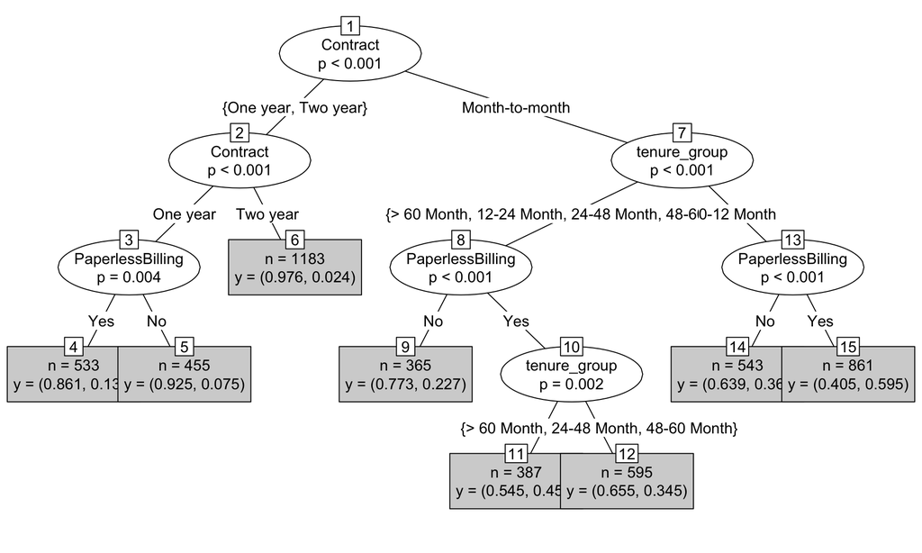

```r
tree <- ctree(Churn~Contract+tenure_group+PaperlessBilling, trainData)
plot(tree, type ="simple")
```

Test the model with test dataset

```r
pred_tree <- predict(tree, testData)
```

Check for Accuracy

```r
p1 <- predict(tree, trainData)
tab1 <- table(Predicted = p1, Actual = trainData$Churn)
tab2 <- table(Predicted = pred_tree, Actual = testData$Churn)
print(paste('Decision Tree Accuracy',sum(diag(tab2))/sum(tab2)))
```

```
## [1] "Decision Tree Accuracy 0.767772511848341"
```

Confusion matrix

```r
print("Confusion Matrix for Decision Tree"); table(Predicted = pred_tree, Actual = testData$Churn)
```

```
## [1] "Confusion Matrix for Decision Tree"
```

```
##          Actual
## Predicted    0    1
##       No  1399  340
##       Yes  150  221
```